# HLA typing for the CTEPH / AGP3K cohort

What the calls are, how good they are, and what they will and will not support

Author

ZHAO TIE

Published

September 8, 2026

**NoteAt a glance**

| **What this is** | HLA genotypes for 3,101 people — 439 CTEPH cases, 2,662 AGP3K controls |
| --- | --- |
| **Delivered as** | `allele_dosage.tsv`, `residue_dosage.tsv`, `residue_diplotype.tsv`, `allele_pgroup_map.tsv` |
| **Failures** | 0 |
| **Agreement with published data** | 11 of 12 comparable loci at *r* ≥ 0.98 |
| **Use first** | class I residues (HLA-A, -B, -C) |
| **Do not use** | DRB3, DRB4 and DRB5 dosages — wrong by construction |
| **Read before analysing** | Section 9, then Section 10 |

**TipWho this is written for, and how to read it**

**Someone who has never worked with HLA.** Section 2 explains the biology and the notation from scratch; nothing after it assumes you read anything else first.

If you already type HLA routinely, read Section 7, Section 9 and Section 10 and skip the rest. If you are here to run an association, those three are the ones that change what you should do.

Every number below is generated from the published tables when this page is built, not typed in by hand. If a table changes and the page is rebuilt, the numbers change with it; if a number here has no source in the data, the build fails rather than printing something stale. Open any grey code block to see exactly which table a number came from.

# 1 What this document is

You are being handed a set of **HLA genotypes** for 3,101 people — 439 CTEPH cases and 2,662 AGP3K controls — so that you can test whether any of them associates with disease. **CTEPH** is chronic thromboembolic pulmonary hypertension, the disease under study; **AGP3K** is the Japanese cohort the controls are drawn from.

This document has one job: to let you use those genotypes **without having to trust them blindly**. It says what was measured, how completely, how well it agrees with published data, and — most importantly — the two specific ways it can mislead you if you are not careful. Section 6 through Section 9 are the quality evidence; Section 10 is the part to read before you design an analysis.

# 2 HLA in five minutes

Skip this section if you already know what `A*24:02` means. Everything after it assumes you have read it — the gene names, the notation, the two different ways a call can be missing, and why DRB3 keeps coming back.

## 2.1 Where these genes are

The **HLA** genes (Human Leukocyte Antigen) are not scattered around the genome. They sit together on the short arm of chromosome 6, at band 6p21.3, inside a region called the **MHC** (Major Histocompatibility Complex): roughly three to four megabases, and one of the most gene-dense stretches of the human genome. MHC is the generic name for that region in any species; HLA is what the human copy of it is called.

The region is conventionally read in three blocks along the chromosome. Starting from the centromeric end: the **class II** genes (DP, DM, DO, DQ, DR), then a **class III** block that contains no HLA genes at all but is packed with other immune genes — complement, TNF — and then the **class I** genes, B and C, then E, then A, with the non-classical G and F furthest towards the telomere. Class III matters here only because it sits between the other two and is inherited with them.

This delivery types 33 genes from that region and turns 19 of them into amino-acid residues. The difference is not a quality filter: the rest are pseudogenes — DRB2, DRB6–DRB9, DPA2 and the class I pseudogenes H, J, K, L, T, V, W and Y — and IPD-IMGT publishes no protein alignment for a gene that makes no protein.

### 2.1.1 You have two copies of chromosome 6, and that is the unit everything is counted in

One copy came from each parent, so you carry **two copies of every gene in this region**, and the two copies can carry different alleles — that is what it means to be heterozygous.

From Section 6 onward, every count in this document is per **chromosome copy**, not per person. The 2,662 controls therefore contribute twice that many copies at a locus where everyone was typed. So a figure of a few thousand “control chromosomes” is not a few thousand different chromosomes: it is this cohort, counted twice over. Frequencies have to be counted that way, because a person carries an allele zero, one or two times and counting heads would throw that distinction away.

It also explains a number that otherwise looks broken. DRB3, DRB4 and DRB5 are missing outright from many copies (below), so their denominator is not the full count — DRB3 is called on 47.7 % of control chromosomes, and only the copies that actually carry the gene are counted. That difference is the whole of Section 7.8.

## 2.2 Class I and class II do the same job on different threats

An HLA protein holds a short fragment of another protein — a **peptide** — in a groove on its outer surface and displays it, so that passing T cells can inspect what the cell is carrying. That is the whole function. The two classes differ in where the peptide came from, which cells do the displaying, and who is watching.

|  | class I | class II |
| --- | --- | --- |
| classical genes | HLA-A, -B, -C | HLA-DR, -DQ, -DP |
| how the molecule is built | one variable α chain, plus β2-microglobulin, an invariant partner encoded outside the MHC entirely | two chains, both encoded here: DRA + DRB1/3/4/5, DQA1 + DQB1, DPA1 + DPB1 |
| displayed by | every nucleated cell | antigen-presenting cells — dendritic cells, macrophages, B cells, thymic epithelium |
| peptide source | proteins made *inside* the cell: its own, a virus’s, a tumour’s | proteins taken in from *outside* and broken up in endosomes |
| peptide shape | short, groove closed at both ends | longer, groove open at both ends |
| inspected by | CD8 T cells | CD4 T cells |
| what a recognised peptide triggers | kill this cell | help — antibody production, cytokines, T-cell help |

Four of the genes typed here are class II but present nothing: **DMA, DMB, DOA and DOB** encode the machinery that loads and edits peptides onto the class II molecules rather than the molecules themselves. They are nearly invariant, which is why they contribute almost no testable positions in Figure 1 (d). The same is true of **DRA**: the DR α chain barely varies, so essentially all DR variation lives on the β chain — DRB1, and the DRB3/4/5 genes below.

The class I genes **HLA-E, -F and -G** are called *non-classical*. They are far less variable than A, B and C and do specialised work — E reports on the health of the classical class I supply to natural killer cells, G is expressed at the maternal–foetal interface. They are typed here and they are informative about typing quality, but they are not where a classical disease association is expected to be.

## 2.3 Why this is the most variable region in the genome

Which peptides an HLA molecule can hold is decided by the shape of its groove, and the groove is built from a handful of amino acids that line it. A population in which everyone carried the same groove could be emptied by a single pathogen whose peptides that groove cannot hold. Selection therefore rewards **being different from your neighbour**, and the result is a locus with tens of thousands of known versions, where the common ones are held at appreciable frequency for a very long time instead of drifting away.

Two things follow that matter for the rest of this document. The variation is **concentrated**: it clusters in the exons that build the groove, and the rest of each gene is comparatively quiet. And because the variation changes what the immune system can see, HLA is associated with more diseases than any other region of the genome — autoimmunity, infection, transplant rejection, drug hypersensitivity. If a disease has an immune component, HLA is worth testing.

## 2.4 The MHC is inherited in blocks

Recombination is suppressed across much of the MHC, so alleles at neighbouring genes are not inherited independently. They travel as **haplotypes** — fixed combinations that recur in a population far more often than chance would give — and the statistical shadow of that is **linkage disequilibrium**: knowing someone’s HLA-B allele tells you a great deal about their HLA-C and often about their DRB1. Some of these blocks are megabases long and population-specific; the Japanese haplotype carrying `A*24:02`, `C*12:02`, `B*52:01`, `DRB1*15:02` and `DQB1*06:01` together is a well-known example.

**NoteWhat this costs you when you interpret a result**

An HLA association is a statement about a **block**, not about a gene, until you do extra work to say otherwise. A signal at DQB1 may be carried by the DRB1 allele beside it, or by a class III gene between them. Two consequences are practical: **you cannot localise a hit to one gene from association statistics alone**, and the 3,125 residue columns in this delivery are nowhere near 3,125 independent tests. Conditional analysis — refitting with the strongest signal held fixed — is the usual next step, and it is honest about how rarely it separates neighbours cleanly.

## 2.5 Typing is a matching problem, not a base call

For an ordinary variant you read one position and report one of two letters. HLA does not work that way. The genes are so variable that the useful question is not “which letter is at this position” but **“which of the thousands of known versions of this gene is this?”** — and you have two of them, one from each parent.

So typing is a *matching* problem. Take the reads from the HLA region, compare them against a catalogue of every version anyone has ever deposited, and decide which pair of catalogue entries explains the reads best. The catalogue is **IPD-IMGT/HLA**, the international registry that both names alleles and publishes their sequences; this run used release 3.64.0, held as a fixed copy on our own disk. That pinning matters: the public catalogue is revised several times a year, alleles gain fields and occasionally get renamed, and a reference that moves under a study is not a reference.

One property of matching is worth stating plainly, because Section 9 turns on it: **a version that is not in the catalogue cannot be returned.** A genuinely novel allele is never reported as novel; its reads are assigned to the closest catalogued neighbour.

## 2.6 What “a call” is here, and why short reads make it hard

A **call** is the pair of catalogue alleles that best explains one person’s reads at one gene, produced by HLA-HD 1.7.1. It is not a base call and it carries no per-call probability. Three things make that hard to get right from short-read whole-genome sequencing.

The differences that separate two alleles are spread along the gene, usually further apart than a single read or read pair spans, so which difference sits on which chromosome has to be inferred rather than seen. The reference genome carries **one arbitrary version** of each HLA gene, so reads from a divergent allele mismatch it badly and map somewhere else or nowhere at all — which is why the reads behind this delivery were pulled from every alternate and HLA-specific contig in the reference as well as from chromosome 6 itself. And the genes resemble one another: DRB1 and DRB3/4/5 are close paralogues, as are A, B and C and the class I pseudogenes beside them, so reads from one gene are readily attracted to another.

When several catalogue pairs fit the reads equally well the program says so, and this dataset carries 2,558 such **ambiguous** results out of 102,333 (sample, gene) calls. That flag is the closest thing to a confidence score the method offers. **`failed` is the label that would mean something went wrong, and it occurs 0 times here.**

## 2.7 How to read an allele name

A version of an HLA gene is called an **allele**, and its name is a structured address, not an arbitrary label:

```
A * 24 : 02 : 01 : 03
│   │    │    │    └── field 4: a difference outside the protein-coding part
│   │    │    └─────── field 3: a DNA difference that does NOT change the protein
│   │    └──────────── field 2: a difference that DOES change the protein
│   └───────────────── field 1: the allele group, roughly the old serological type
└───────────────────── the gene, also called the locus

A * 24 : 09 N
            └── expression suffix: this allele is transcribed but no protein
                reaches the cell surface, so this chromosome presents nothing
                at HLA-A — even though its name looks like an ordinary A*24
```

The fields run from most consequential to least, and every allele has at least the first two. The optional trailing letter is an **expression suffix**, and it overrides everything to its left:

| suffix | means | why it matters |
| --- | --- | --- |
| `N` | **null** — no protein on the cell surface | that chromosome is functionally empty at that gene, however normal the rest of the name looks |
| `L` | low surface expression | present, but at a level that may not behave like a full copy |
| `S` | secreted — the protein exists but is soluble, not on the membrane | the same caveat, for a different reason |
| `Q` | expression questionable, not yet established | treat as unresolved rather than as either of the above |

`N` is the one to remember. It is the mechanism behind the DRB4 discussion in Section 7, where the reference panel uses a null allele to mean “this haplotype has no working DRB4”. Note also that **the names in this delivery never carry a suffix** — our caller does not write them (Section 7) — so nothing in `allele_dosage.tsv` announces itself as null.

## 2.8 Why this delivery stops at two fields

**Field 2 is where the protein changes**, so it is the last field that changes what the molecule can display. Everything beyond it is either silent at the protein level (field 3) or outside the coding sequence entirely (field 4). This delivery therefore reports `A*24:02` and stops.

That is a choice, but not much of one. Deeper fields are read from intronic and untranslated sequence that short-read data covers unevenly, so they are the least reliable part of a call: the deepest resolution reached anywhere in this dataset is field 3, and 0 calls carry a fourth. Published population data is written at two fields as well, so a deeper delivery could not have been compared against anything.

## 2.9 The antigen recognition domain

Not all of an HLA protein is doing the presenting. The part that forms the groove and contacts the peptide is the **antigen recognition domain** (ARD): the α1 and α2 segments for class I, the α1 or β1 segment for class II — in DNA terms, exons 2 and 3 for a class I gene and exon 2 for a class II gene.

The ARD is the natural unit for asking whether two alleles are functionally the same, and IPD-IMGT uses it exactly that way: alleles whose protein is identical **across the ARD** are collected into a **P group**, named after the lowest-numbered member with a `P` appended. `DRB3*01:01P` is not an allele; it is a group of alleles that differ only outside the groove. Reference panels frequently publish at that resolution, which is what Section 7 is about. The genotypes you were given are not P-grouped.

## 2.10 Residues, and why they are often the better test

A **residue** is one amino acid at one position in the protein. Because a `GENE:position:aminoacid` combination is shared by many different alleles, a residue test asks a more robust question than an allele test:

|  | allele test | residue test |
| --- | --- | --- |
| what you regress on | one column of `allele_dosage.tsv`, e.g. `DRB1*15:01` | one column of `residue_dosage.tsv`, e.g. `DRB1:11:P` |
| the question it asks | “do people carrying `DRB1*15:01` get the disease more?” | “do people with a proline at DRB1 position 11 get it more?” |
| number of things tested | many, most of them rare | fewer, most of them common |
| if one rare allele is mis-called | that allele’s result is wrong | usually unchanged — the allele it was confused with carries the same amino acid at most positions |
| what it cannot do | — | name the allele responsible; a residue is shared across many |

Concretely: this cohort carries 2,298 distinct two-field alleles, and the protein variation underneath them reduces to 1,297 varying amino-acid positions. The same evidence, in fewer and commoner columns.

Positions are numbered as IPD-IMGT numbers them, on the mature protein, which is why you will see negative positions such as `A:-21:M` — those lie in the signal peptide that is cut off during processing. Both matrices are delivered; Section 10 says which to trust when they disagree.

## 2.11 Genes you may not have: DRB3, DRB4 and DRB5

Most genes come in two copies. The DR region does not work that way. Every haplotype carries DRA and DRB1, but whether it carries a *second* expressed β chain gene — and which one — depends on the DRB1 allele it carries. The haplotype groups have names of their own:

| haplotype group | second β gene | carried with DRB1 groups |
| --- | --- | --- |
| DR51 | DRB5 | `DRB1*15`, `DRB1*16` |
| DR52 | DRB3 | `DRB1*03`, `*11`, `*12`, `*13`, `*14` |
| DR53 | DRB4 | `DRB1*04`, `*07`, `*09` |
| — | none | `DRB1*01`, `*08`, `*10` |

So a person can genuinely carry **two copies, one copy, or none** of DRB3, DRB4 or DRB5, and the fraction of this cohort in whom each gene was found at all reflects exactly that: 0.4673 for DRB3, 0.5769 for DRB4 and 0.3612 for DRB5. That is biology, not a sequencing failure, and it produces two of the outcome labels you will see in Section 6:

- **hemizygous** — one copy present, one genuinely absent.
- **not typed** — the gene is absent from that person’s haplotype altogether.

Neither means anything went wrong. It does mean that the dosage columns for these three genes cannot be read like the others, that the reference comparison at DRB3 breaks down (Section 7.8), and that these are the genes Section 10 tells you not to use.

# 3 What you are getting

Four tables, all keyed on `sample_id`, all covering exactly the same **3,101** people.

| file | shape | one column is | one cell is |
| --- | --- | --- | --- |
| `04.residues/allele_dosage.tsv` | 3,101 × 2,298 | one 2-field allele, e.g. `A*24:02` | how many copies (0, 1, 2) |
| `04.residues/residue_dosage.tsv` | 3,101 × 3,125 | one `GENE:position:aminoacid` | how many copies (0, 1, 2) |
| `04.residues/residue_diplotype.tsv` | 3,101 × 1,297 | one `GENE:position` | the unordered pair of amino acids |
| `05.qc/allele_pgroup_map.tsv` | one row per allele | — | whether a published Japanese panel lists this allele at all |

The first two are what you will regress on. The fourth is the safety check Section 9 tells you to apply before testing a rare allele.

**WarningRead `sample_id` as a string, always**

66 of the 3,101 sample ids begin with a zero. `pandas.read_csv` without `dtype` turns the column into an integer and silently deletes those zeros; an inner join then returns 3,035 rows instead of 3,101, with no error and no warning.

```python
pd.read_csv(path, sep='\t', dtype={'sample_id': str})
```

# 4 Which people these cover

Three filters were applied in order, and **they are not the same kind of decision**.

**show the code that produced this number**

```r
data.frame(
  step = c("1. in the v6 study cohort", "2. passed sequencing quality control",
           "3. **in the mainland ancestry cluster**"),
  `what it selects for` = c("being part of this study at all",
                            "the genome-wide data being usable",
                            "**sharing an ancestry background**"),
  remaining = c(f("n_v6_flagged"), f("n_qc_pass"), f("n_typed")),
  removed = c("—", f("n_dropped_sample_qc"), f("n_dropped_ancestry")),
  check.names = FALSE
) |> kable()
```

| step | what it selects for | remaining | removed |
| --- | --- | --- | --- |
| 1. in the v6 study cohort | being part of this study at all | 3,592 | — |
| 2. passed sequencing quality control | the genome-wide data being usable | 3,569 | 23 |
| 3. **in the mainland ancestry cluster** | **sharing an ancestry background** | 3,101 | 468 |

Step 2 is a **quality** decision: 23 people whose genome-wide heterozygosity was anomalous were dropped upstream. For HLA typing those are exactly the samples least likely to resolve cleanly into two versions of a gene, so inheriting that decision is the right thing to do.

Step 3 is an **ancestry** decision, and it is the one worth understanding, because Section 9 depends on it. The only external check available for HLA calls is *“does the allele we called appear in a published Japanese reference panel?”*. A control who is not of the same ancestral background as that panel will fail that check for reasons that have nothing to do with typing quality. Restricting the cohort first removes that explanation by construction.

The 468 people removed at step 3 were typed, and their results are **not deleted** — they are kept under `results/_superseded.3569/`. Extending to a wider sample set later costs a re-run of one collection script, not a re-run of the typing.

# 5 How the typing was done

- **Reads** were taken from the whole HLA region of chromosome 6, plus every alternate and HLA-specific contig in the reference genome the data were aligned to — HLA is variable enough that reads from an unusual version will not map to the single “standard” copy.
- **HLA-HD 1.7.1** matched those reads against a **pinned** copy of the IPD-IMGT/HLA 3.64.0 catalogue. Pinned means a fixed copy on our own disk: the public catalogue is updated several times a year, and a reference that moves under a study is not a reference.
- **33 genes** were typed. IPD-IMGT publishes a protein alignment for **19** of them, and only those can be turned into residues.
- **Residues come from IMGT’s own published alignment**, never from a re-computed one, so “DRB1 position 11” means the same position everyone else means by it.
- Of the 5,957 positions in that alignment, **1,297 actually vary in this cohort** and are the ones delivered. A position where everybody has the same amino acid carries no information.

# 6 How complete is it?

**0 (sample, gene) failures across the entire dataset.** That is not luck. The typing program exits successfully even when it has crashed internally, so every result is checked *inside* the typing job and a truncated result fails that job rather than being quietly published.

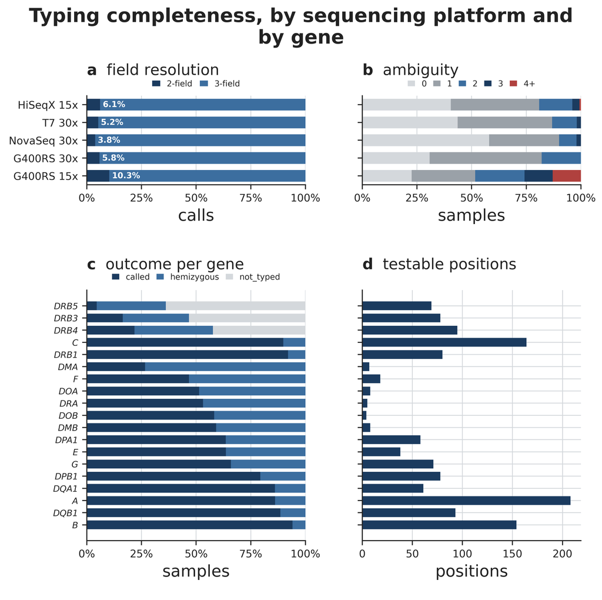

Figure 1: Typing completeness, by sequencing platform and by gene. Read it by platform, not by case/control — see the note after panel (b).

## 6.1 What you are looking at

Four views of “was a call produced, and how good was it”, none of which can tell you whether a call is *correct* — that is Section 8.

**(a) field resolution** — For each sequencing platform, what fraction of calls resolved to 2 fields and what fraction to 3. Remember from Section 2 that field 2 is where the protein changes: a 2-field call is already enough for everything in this delivery, and a 3-field call is a bonus. The printed white number is the 2-field share, so **a bigger number means slightly less resolved calls**. The spread across platforms is 3.8 % on NovaSeq 30x to 10.3 % on DNBseq-G400RS 15x — real, but small.

**(b) ambiguity** — For each platform, how many samples had 0, 1, 2, 3 or 4+ genes where the program could not choose between several equally good answers. This is the closest thing to a per-call confidence score the method offers.

**(c) outcome per gene** — For each of the 19 genes that carry residues, the fraction of people in each outcome. **This is the panel most likely to be misread.** The three bars at the top — DRB5, DRB3, DRB4 — look bad and are not: their grey `not_typed` block is the biology from Section 2, those genes being genuinely absent from many haplotypes. There is no `failed` category drawn because there were no failures.

## 6.2 What to conclude

Completeness is essentially saturated, so it is a *weak* quality signal here: the call rate takes only 5 distinct values across the whole cohort and 97 % of people sit on two of them. That is why every panel is a composition rather than an average — an average over a saturated measurement hides the only variation there is.

## 6.3 What this figure cannot tell you

Whether any call is *right*. Every measurement here is about whether a call was produced and how finely, not whether it names the correct version of the gene.

## 6.4 Why by platform, and not by case/control

Every control was sequenced on one machine type and every case on a different one, with no overlap. Any case/control difference in these metrics is therefore inseparable from the machine, which is why the comparison is never drawn that way. This becomes the central issue in Section 9.

# 7 How two sources of allele frequencies are made comparable

Section 8 compares our allele frequencies with a published panel’s. Before it can, the two have to be talking about the same things. They are not, to begin with, and the work of making them so is worth understanding, because it is where one locus turns out to be uncomparable.

**NoteThree words the rest of this section rests on**

An allele’s **frequency** is the share of *chromosomes* in a group that carry it: copies divided by chromosomes counted, not by people, because every person contributes two of them at every gene. The **denominator** is the set of chromosomes being divided by — and two frequencies can only be compared when both sides are dividing by the same kind of set. To **renormalise** is to rescale what is left after some chromosomes are taken out of that set, so that the frequencies still add up to one. Everything below is one of those three going right, and Section 7.8 is one of them going wrong.

## 7.1 Three sources, three ways of writing the same allele

|  | how it writes an allele |
| --- | --- |
| us (HLA-HD) | `DRB3*01:01` — never any suffix |
| jMorp 61KJPN-HLA | **a mixture**: 447 of its 1,445 names end in `P`, the other 998 do not |
| 1000 Genomes JPT | `23:01` — bare, never any suffix |

Nothing can be joined until these are in one namespace.

## 7.2 What the `P` means

IPD-IMGT groups together alleles whose protein is **identical over the part that matters for binding** — the antigen recognition domain — and names the group after its lowest-numbered member with a `P` appended. `DRB3*01:01P` is not an allele; it is a group of more than a hundred of them, of which our cohort carries 6.

The group exists because those alleles differ only outside the binding groove. For a frequency comparison they are the same thing; for a residue analysis they are not, which is why this translation stops at the QC boundary (see below).

**Not every allele has a group.** A group of one gets no name, so `DRB1*15:13` — whose protein sequence in that region is unique — appears with no `P`. That is why the reference panel’s naming looks inconsistent: it is not inconsistent, it is exact.

## 7.3 The translation runs in one direction, and only one direction is possible

Ours → group is **many-to-one**: well defined, and lossy only in a way that will be quantified below. Group → ours is **not invertible**: jMorp publishes one number for `DRB3*01:01P` — the sum over all its members — and the split between members is information nobody has.

Not translating at all is not an option either, and that is measured rather than assumed. Join our raw names straight against jMorp’s own names and **98.97 %** of our control chromosomes find no partner at all; at 3 loci (DQA1, E, F) not one chromosome matches. The comparison would not be worse without the translation — it would not exist.

## 7.4 Both sides are normalised, not one

A reference name that already ends in `P` passes through untouched; one that does not is looked up. Our names go through the same lookup. **The two therefore meet at whichever convention is finer for that particular allele** — the full two-field name where the reference kept it, the group name where the reference had already merged it.

At the compared loci we carry 2,142 alleles, of which **1,289 keep their name exactly**.

## 7.5 What the merging costs

576 of our alleles fall into 102 groups that contain more than one of them, so **474 distinct names disappear from the comparison**. They disappear only where the reference had already merged them, so nothing is lost that the comparison could have used.

**ImportantNone of this reaches the genotypes you were given**

`allele_dosage.tsv` and `residue_dosage.tsv` contain **no P groups**. They carry the untranslated two-field names, because a group merges alleles that differ outside the binding region and the residue analysis reads the whole protein. Collapsing the delivered matrices onto groups would take 2,298 columns down to 1,788 and throw away testable variation.

## 7.6 The two-field key, and the check that makes it legal

The lookup is keyed on the two-field name, because that is the depth everything here runs at. That is only valid if **no two-field name ever spans two different groups** — otherwise the collapse would be arbitrary. The code checks all 25,290 of them and aborts rather than choosing one, so if a future IPD-IMGT release ever breaks the property, the pipeline stops instead of quietly producing a wrong comparison.

## 7.7 Denominators: what is left out, and why

A frequency needs a denominator, and the two sources must use the same one.

- **Chromosomes where we made no call are excluded from ours.** For DRB3, DRB4 and DRB5 that is most of them, and correctly so — Section 2 explains that those genes are genuinely absent from many haplotypes.
- **Null alleles are dropped from the reference and the rest renormalised.** jMorp uses the null allele DRB4*03:01N — 0.543 of all its chromosomes — to mean “this haplotype has no working DRB4”. That is the same fact our data records as* not typed*. Keeping it would compare two different quantities: the reference would be spending more than half its chromosomes on an allele we never call, and DRB4 would report* r* = 0.624. Dropping it and renormalising gives *r* = 0.9909.

## 7.8 Where this fails: HLA-DRB3

**jMorp provides no null allele for DRB3**, yet its DRB3 counts still add up to every chromosome in the panel.

|  | ours | jMorp |
| --- | --- | --- |
| chromosomes carrying DRB3 | 47.7 % | 100 % |

100 % is not possible: DRB3 exists only on one family of haplotypes. So the panel is assigning a real DRB3 allele to chromosomes that do not carry the gene, and they land mostly on the commonest one. Our denominator is the 47.7 % that do carry it.

The two numbers are not the same quantity, so the correlation between them measures the mismatch and not the typing. **DRB3 is therefore marked not comparable and excluded from the headline**, drawn hollow in Figure 2 (b) and flagged with a dagger. Every other locus agrees with the reference to within 0.7 percentage points on this fraction — except DRB4, which is 11.2 points out for the reason just given, and DRB3, which is 52.3 points out with no such reason available.

The test is mechanical, not a special case for DRB3: a locus is marked uncomparable when the reference covers essentially every chromosome while we call the gene on materially fewer. DRB4 is not caught by it, and should not be: the 45.6 % of reference chromosomes it puts on a real DRB4 allele is an honest fraction, not a saturated one.

# 8 Do the calls agree with published data?

Completeness cannot see a call that was made confidently and is wrong. The only thing that can, without re-typing samples of known type, is this: **if we call alleles correctly, the frequencies we observe in our controls should reproduce the frequencies published for a comparable population.** If the typing were systematically picking the wrong version, the whole frequency spectrum would shift and no completeness metric would notice.

Concordance below is reported as *r*: one number per locus for how closely our frequency for each shared allele tracks the reference’s, with 1 meaning every allele sits exactly on the diagonal. It is dominated by the few common alleles, so a high *r* is not a guarantee about the rare ones — which is what the second and third panels are for.

Getting the two sources into the same namespace is Section 7; this section reads the result.

**11 of the 12 comparable loci reproduce the reference at a correlation of 0.983 or better.** The 1 locus left out is HLA-DRB3, for the reason given in Section 7.8.

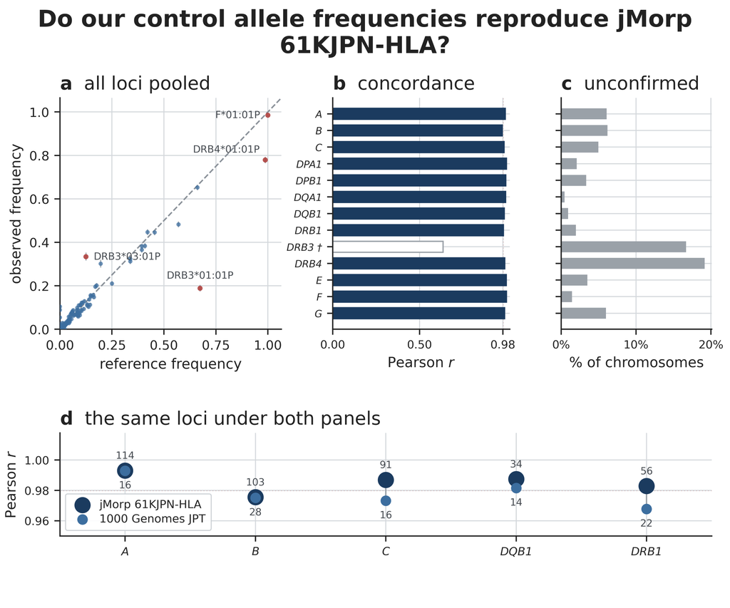

Figure 2: Our control allele frequencies against the reference panels. Panel (d) is the comparison between the two panels themselves.

## 8.1 Reading the figure, panel by panel

**(a) all loci pooled** — One dot per allele. The horizontal position is the frequency the reference publishes; the vertical position is the frequency we observe in our controls. **A dot on the dashed line means we and the reference agree.** The vertical bars are 95 % confidence intervals on our estimate. Red dots are the two commonest alleles and the three furthest from the line, named so you can see which they are.

**(c) unconfirmed share** — For each locus, the fraction of our control chromosome copies carrying an allele the reference **does not list at all**. This is a different question from (b): a locus can have excellent correlation on the alleles both sources share and still put many chromosomes onto alleles the reference has never seen. Drawn on the same rows as (b) so the two can be read together.

**show the code that produced this number**

```r
sm <- tsv("05.qc/allele_frequency_summary.tsv")
sm[, c("gene", "n_alleles", "n_shared", "n_chr_ctrl", "pearson_r", "max_abs_diff",
       "allele_at_max")] |> kable()
```

| gene | n_alleles | n_shared | n_chr_ctrl | pearson_r | max_abs_diff | allele_at_max |
| --- | --- | --- | --- | --- | --- | --- |
| A | 552 | 114 | 5324 | 0.9930 | 0.0299 | A*26:01P |
| B | 546 | 103 | 5324 | 0.9755 | 0.0313 | B*40:02P |
| C | 442 | 91 | 5322 | 0.9869 | 0.0347 | C*03:04P |
| DPA1 | 33 | 6 | 5324 | 0.9998 | 0.0125 | DPA1*01:03P |
| DPB1 | 193 | 41 | 5324 | 0.9966 | 0.0401 | DPB1*02:01P |
| DQA1 | 27 | 8 | 5324 | 0.9957 | 0.0254 | DQA1*03:01P |
| DQB1 | 128 | 34 | 5324 | 0.9874 | 0.0253 | DQB1*06:01P |
| DRB1 | 285 | 56 | 5324 | 0.9828 | 0.0234 | DRB1*15:13 |
| DRB3 | 101 | 10 | 2540 | 0.6352 | 0.4852 | DRB3*01:01P |
| DRB4 | 78 | 3 | 3028 | 0.9909 | 0.2083 | DRB4*01:01P |
| E | 34 | 2 | 5324 | 0.9991 | 0.0262 | E*01:01P |
| F | 15 | 2 | 5324 | 1.0000 | 0.0150 | F*01:01P |
| G | 18 | 5 | 5324 | 0.9896 | 0.0880 | G*01:01P |

## 8.3 The per-locus record

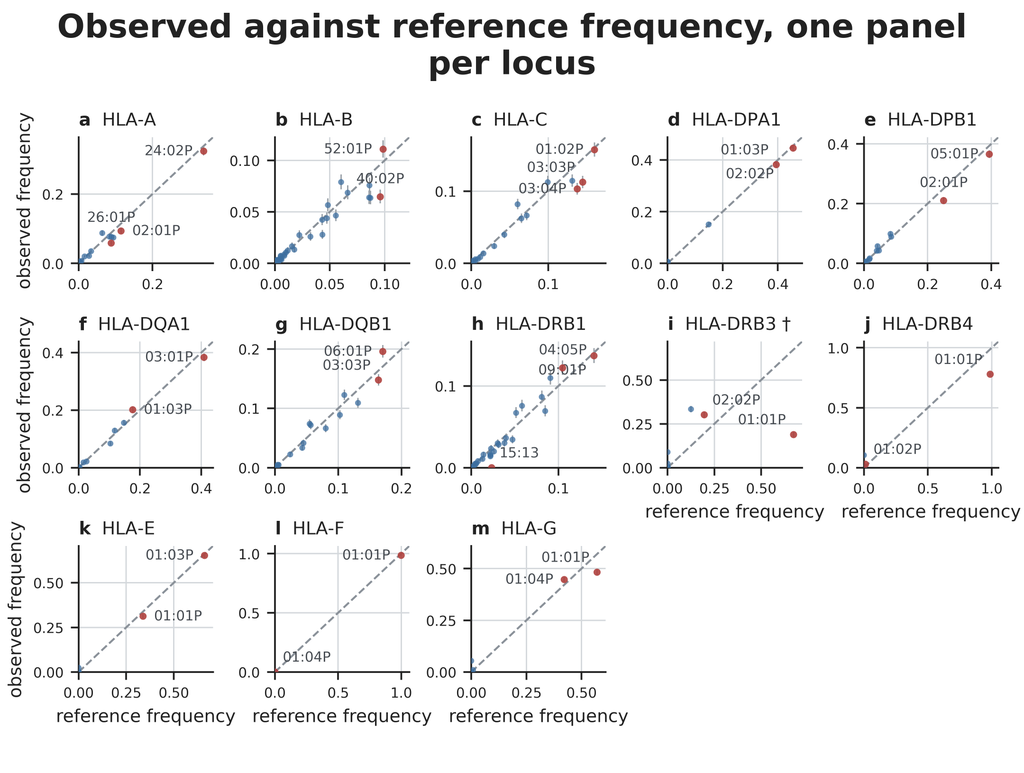

Figure 3: The same comparison, one panel per locus. This is the record behind Figure 2, not a separate argument.

Each panel is the same plot as Figure 2 (a) restricted to one locus. **The axes are scaled to each locus separately**, so panels cannot be compared with each other by eye — that is what Figure 2 (b) is for. Panel (i), HLA-DRB3, is the one to look at: its three commonest alleles sit visibly off the line in both directions.

**ImportantHLA-DRB3 is excluded, and the reason is now known**

Earlier versions of this document said that no mechanism we had tested accounted for the DRB3 gap. **That is no longer true.** The reference panel has no way to say “this chromosome has no DRB3” and so assigns one anyway; our denominator counts only the chromosomes that carry the gene. Section 7.8 has the numbers. The comparison is invalid at this locus rather than merely poor, which is why the bar in Figure 2 (b) is drawn hollow and the locus is not counted in the headline.

This changes a quality metric, not the delivered genotypes — DRB3 dosages were already marked *do not use*, for the separate reason in Section 10.

# 9 The one real quality problem

This is the section that most constrains what these genotypes can support.

Define **“unconfirmed”** as: a chromosome copy carrying an allele that the reference panel does not list. Some unconfirmed calls are expected — no panel contains every rare allele. The problem is not the level. **The problem is that the level differs between our cases and our controls.**

**Controls: 4.63 % of called chromosomes. Cases: 3.53 %.** A ratio of **1.31**, Fisher exact *P* = 1.89e-07. A *P* value is the chance of seeing a gap at least this wide if the two groups really had the same underlying rate, so a number this small means the gap is hard to put down to luck.

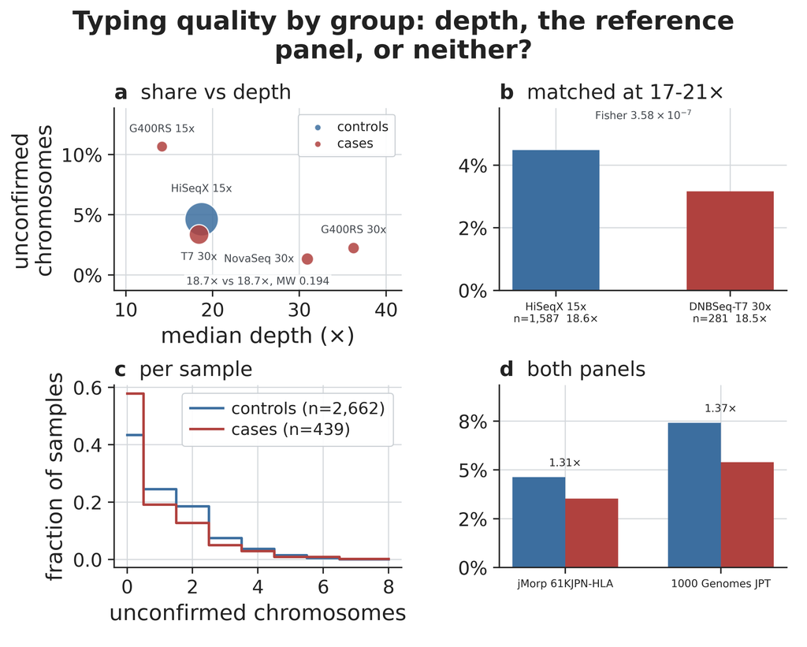

Figure 4: Testing the two explanations that would make the case/control difference go away.

Three things could produce that difference. Two of them are tested here and neither survives.

**(a) share vs depth** — One dot per sequencing platform. Horizontal: how much sequence data that platform produced per person (its median depth). Vertical: the unconfirmed share. Dot area is proportional to the number of people. **Read it twice.** First along the *case* platforms alone — phenotype is held constant there, and the share clearly falls as depth rises, so depth genuinely does matter. Then compare the large blue control dot with the case dot sitting immediately below it at the same depth: same depth, different share. The note inside the panel gives the two group medians and a test of whether they differ: 18.72× against 18.65×, *P* = 0.194. **They do not.**

**(b) matched at 17–21×** — The same comparison restricted to people whose actual depth falls in a narrow window where the two largest platforms have equal medians. If depth were the cause, these two bars would be level. They are not: 4.48 % against 3.16 %, *P* = 3.58e-07.

**(d) both panels** — The same case/control comparison computed twice, against two different reference panels, from *identical* calls. The number above each pair is the control/case ratio.

## 9.1 Why panel (d) matters more than it looks

“Unconfirmed” is defined by whichever reference panel you choose, so the obvious objection is that the whole finding is an artefact of that choice. Panel (d) tests it, and the two panels differ in **two ways at once**:

|  | jMorp 61KJPN-HLA | 1000 Genomes JPT |
| --- | --- | --- |
| individuals | 61,424 | 105 |
| loci covered | 13 | 5 |
| population sampled | Tohoku, north-east Japan | Tokyo region |
| unconfirmed, controls | 4.63 % | 7.42 % |
| unconfirmed, cases | 3.53 % | 5.40 % |
| **control/case ratio** | **1.31** | **1.37** |

Neither panel is simply better. The larger one has seen far more of the rare Japanese allele repertoire, which is why it leaves less unconfirmed. The smaller one samples a population plausibly closer to our own cohort, but at a size where it cannot have observed an allele carried by fewer than about one person in a hundred. Our cohort is neither of those two populations; on the evidence of where it sits in Japanese population-structure analyses, it lies between them.

**So the level moves a great deal between the two panels and the ratio barely moves at all.** The absolute number belongs to the reference; the difference between our two groups does not. That is a demonstration, not an assurance — and it is the reason this figure runs both panels on every execution rather than picking one.

**NoteThe third explanation — ancestry — was removed before the data were produced**

A control whose ancestry differs from the reference panel’s would carry alleles the panel has not seen, for reasons unrelated to typing. That is why the cohort was restricted to a single ancestry cluster in Section 4 **before** any of these numbers were computed. Before that restriction the same comparison gave 4.74 % against 3.57 %, a ratio of 1.33. Removing the benign explanation left the finding essentially unchanged.

## 9.2 What is left, and what it means for you

Not depth. Not the reference panel. Not ancestry. **What remains is the sequencing platform** — and every control was sequenced on one platform and every case on another, with no overlap at all. Platform, cohort and phenotype are perfectly **confounded** — they always change together in this data, so a difference could be caused by any of them and no statistic can tell them apart. It is not possible from these data to say which of read length, library chemistry, alignment behaviour or batch is responsible.

**WarningThe practical consequence, stated plainly**

If a common allele is under-called slightly more often in controls than in cases, it will look like that allele is **enriched in cases** — a false disease association produced entirely by the typing.

# 10 Data quality, and how to run the association

Everything before this chapter is evidence. This one states what the evidence adds up to, gives you the two tables that carry it column by column, and says what to do with them.

## 10.1 What the quality evidence adds up to

**The typing itself is sound, and the one real problem is not in the typing.**

0 (sample, gene) calls failed anywhere in the dataset, and completeness is so nearly saturated that it is a weak signal rather than a discriminating one — the call rate takes 5 distinct values across the whole cohort (Section 6). Against published Japanese frequencies, 11 of the 12 comparable loci reproduce the reference at *r* ≥ 0.98 (Section 8). HLA-DRB3 is excluded from that count because the panel and this pipeline are not counting the same chromosome copies there, which is a defect of the comparison and not of the calls (Section 7.8).

**The one real problem is that controls carry more unconfirmed alleles than cases** — 4.63 % against 3.53 %, a ratio of 1.31 — and every explanation that would have made it disappear was tested and did not (Section 9). What remains is the sequencing platform, which is perfectly confounded with case/control status. That is the fact this chapter’s advice is built around.

**What is not established anywhere in this delivery.** There is no per-sample accuracy measurement. The frequency check compares *population frequencies*, so a set of errors that happened to preserve the overall spectrum would be invisible to it. Settling that would require typing samples whose HLA type is already published, which is scoped and deferred in `docs/OPEN_QUESTIONS.md` §2.

## 10.2 Quality per allele and per residue

Two tables answer “should I test this column?” for every column of the two matrices, one row each:

| file | one row per | rows |
| --- | --- | --- |
| `05.qc/allele_quality.tsv` | column of `allele_dosage.tsv` | 2,298 |
| `05.qc/residue_quality.tsv` | column of `residue_dosage.tsv` | 3,125 |

**Neither carries a usable/unusable verdict, deliberately.** Where that line falls depends on the model you fit, so the tables publish the counts and the flags and leave the decision to you. The columns that matter most:

| column | what it tells you |
| --- | --- |
| `n_chr_ctrl`, `n_chr_case`, `n_chr_total` | how many chromosome **copies** carry this column — two per person, not one — the evidence behind any test of it |
| `freq_ctrl`, `ci_lo_ctrl`, `ci_hi_ctrl` | the control frequency and its Wilson interval |
| `in_reference`, `freq_reference` | whether a published Japanese panel lists this allele, and at what frequency |
| `n_chr_ambiguous`, `share_ambiguous` | how much of this allele’s support came from calls the program had to resolve itself (`docs/OPEN_QUESTIONS.md` §5) |
| `gene_comparable` | 0 where the locus could not be checked against the panel at all |
| `gene_dosage_valid` | 0 for DRB3/4/5, whose dosages are wrong by construction |
| `n_alleles_carrying` | *(residues)* how many of this cohort’s alleles carry this amino acid here |
| `position_undetermined_rate` | *(residues)* the share of samples whose dosages at this position do not sum to 2 |

**The allele table is a long tail, and that is the single most important thing to know before testing it.** Of 2,298 allele columns, 1,300 are carried by exactly one chromosome and 2,021 by fewer than ten. The 277 columns at ten or more carry 97.93 % of all chromosomes between them. So almost every column is rare and almost every chromosome is common — testing the whole matrix unfiltered means spending nearly all of your multiple-testing budget on columns that cannot reach significance.

251 alleles have at least one chromosome from a resolved ambiguity, 2.93 % of all chromosomes. 281 allele columns and 601 residue columns belong to DRB3/4/5 and should be dropped outright.

**The residue table is the opposite shape, which is why Section 2 recommends it.** The median residue is carried by 18 different alleles in this cohort, so a mis-call to a neighbouring allele usually does not move it; 1,837 of 3,125 residue columns reach ten chromosomes, against 277 of the allele columns. 1,211 residues are carried by a single allele and inherit that allele’s fragility exactly.

**show the code that produced this number**

```r
aq <- tsv("05.qc/allele_quality.tsv")
rq <- tsv("05.qc/residue_quality.tsv")
data.frame(
  table   = c("allele_quality.tsv", "residue_quality.tsv"),
  columns = c(nrow(aq), nrow(rq)),
  `MAC >= 10` = c(sum(aq$n_chr_total >= 10), sum(rq$n_chr_total >= 10)),
  singleton   = c(sum(aq$n_chr_total == 1), sum(rq$n_chr_total == 1)),
  `dosage invalid` = c(sum(aq$gene_dosage_valid == 0), sum(rq$gene_dosage_valid == 0)),
  check.names = FALSE) |> kable()
```

| table | columns | MAC >= 10 | singleton | dosage invalid |
| --- | --- | --- | --- | --- |
| allele_quality.tsv | 2298 | 277 | 1300 | 281 |
| residue_quality.tsv | 3125 | 1837 | 744 | 601 |

The positions the residue matrix is least sure of, worst first — a high rate means the reference could not place one of the two chromosomes at that position:

**show the code that produced this number**

```r
p <- unique(rq[rq$gene_dosage_valid == 1, c("gene", "position",
                                            "position_undetermined_rate")])
head(p[order(-p$position_undetermined_rate), ], 8) |> kable(row.names = FALSE)
```

| gene | position | position_undetermined_rate |
| --- | --- | --- |
| DQA1 | 56 | 0.237343 |
| A | 341 | 0.109965 |
| A | 316 | 0.109642 |
| A | 321 | 0.109642 |
| A | 325 | 0.109642 |
| A | 327 | 0.109642 |
| A | 328 | 0.109642 |
| A | 329 | 0.109642 |

## 10.3 Running the association

**In order of robustness, most to least.**

1. **Class I residues (A, B, C).** Most robust. A mis-call to a rare version of the same family typically moves only a handful of the several hundred amino-acid positions, so a residue test barely notices it. If you run one analysis, run this one.
2. **Class II residues (DRB1, DQB1, DPB1, DQA1, DPA1).** A mis-call moves more positions here, but the class II unconfirmed shares are the smallest in the cohort — DQB1 at 0.94 % and DRB1 at 1.97 %.
3. **`allele_dosage.tsv`, common alleles.** Sound, with the `in_reference` check above.
4. **`allele_dosage.tsv`, rare alleles.** Least robust — a rare allele is precisely where the Section 9 differential lives.
5. **DRB3, DRB4 and DRB5 dosages. Do not use them.** See the box below.

And five things about this particular cohort that change what you should do:

- **Filter with the quality tables, not by eye.** Join `allele_quality.tsv` or `residue_quality.tsv` onto your columns and choose a `n_chr_total` floor explicitly. Whatever floor you pick, state it: the tables give you the numbers precisely so that the choice is visible in your methods rather than buried in a script.
- **You cannot adjust for platform.** Every control was sequenced on one machine type and every case on another, with no overlap (Section 9), so platform is not a covariate available to you — a model cannot separate an effect from a variable that is a perfect copy of the outcome. Any result that would change if platform changed has to be reported as such, not adjusted away.
- **Ancestry is already handled, and is also not a covariate.** The cohort was restricted to a single ancestry cluster before any of these numbers were computed (Section 4), which is why the unconfirmed comparison is meaningful at all.
- **A hit names a block, not a gene.** Recombination is suppressed across the MHC (Section 2), so a signal at one locus routinely appears at its neighbours. Conditional analysis — refitting with the strongest signal held fixed — is the expected next step, and it separates neighbours less often than people expect.
- **Residue columns are not independent tests.** There are 3,125 of them, and nothing like that many degrees of freedom: they are built from 2,298 alleles, and neighbouring positions on the same molecule move together. A Bonferroni correction over the raw column count is far too strict, and treating the columns as independent is far too loose.

Report `n_chr_total` beside every result you present. It is the number that decides whether a result deserves attention, and it is now one join away.

**ImportantDRB3/4/5 dosages are wrong by construction**

Section 2 explained that these three genes are genuinely present or absent from a haplotype. A person carrying one copy is hemizygous — but the pipeline writes a hemizygous call as **two copies of the same allele**, so those columns read 2 where the truth is 1.

# 11 Glossary

Every term this document, its figures and the delivered column names use, grouped by the part of the problem it belongs to. Nothing here is assumed knowledge: if a word in the report is not in this table, it is ordinary English.

## 11.1 The biology

| term | 中文 | meaning |
| --- | --- | --- |
| HLA | 人类白细胞抗原 | the gene cluster on chromosome 6 whose proteins display protein fragments to T cells |
| MHC | 主要组织相容性复合体 | the region of chromosome 6, at band 6p21.3, that the HLA genes sit in |
| class I | I 类 | HLA-A, -B, -C (and E, F, G): on every nucleated cell, displaying fragments of what is *inside* it, inspected by CD8 T cells |
| class II | II 类 | HLA-DR, -DQ, -DP: on immune cells only, displaying fragments taken in from *outside*, inspected by CD4 T cells |
| peptide | 肽段 | the short protein fragment an HLA molecule holds in its groove and displays |
| haplotype | 单倍型 | the whole set of alleles inherited together on one chromosome from one parent |
| linkage disequilibrium | 连锁不平衡 | neighbouring HLA alleles travel together far more often than chance, so a signal at one gene routinely appears at its neighbours |
| DR51 / DR52 / DR53 | DR51 / DR52 / DR53 | the older names for the haplotype groups that carry DRB5, DRB3 and DRB4 respectively |
| antigen recognition domain (ARD) | 抗原识别域 | the part of the protein that forms the groove and touches the peptide; exons 2–3 for class I, exon 2 for class II |
| residue | 残基 | one amino acid at one position in the protein |

## 11.2 Naming an allele

| term | 中文 | meaning |
| --- | --- | --- |
| allele | 等位基因 | one specific known version of a gene |
| genotype | 基因型 | what a person actually carries at one place in the genome — here a *pair* of alleles, not a single DNA letter |
| locus | 位点 | a fixed place in the genome; in this document, one HLA gene |
| field | 字段 | one colon-separated number in an allele name; field 2 is where the protein changes |
| 2-field | 二字段 | the resolution used throughout this delivery, e.g. `A*24:02` |
| serological type | 血清型 | the pre-DNA way of typing HLA, by testing blood against antibodies; those older names survive as field 1 |
| expression suffix | 表达后缀 | the trailing `N`, `L`, `S` or `Q` on some allele names, describing whether and how the protein reaches the cell surface |
| null allele | 空等位基因 | an allele written with a trailing `N`: the gene copy is there in the DNA but makes no working protein |
| P group | P 组 | alleles whose protein is identical across the ARD, collected under the lowest-numbered member with a `P` appended; how the reference panels name things |
| IPD-IMGT/HLA | IPD-IMGT/HLA | the international catalogue of known HLA alleles, both names and sequences |

## 11.3 What a call is

| term | 中文 | meaning |
| --- | --- | --- |
| typing | 分型 | deciding which two known versions of a gene a person carries |
| call | 分型结果 | the answer the program commits to for one person at one gene |
| call rate | 分型率 | the share of attempts that produced an answer at all |
| called | 已定型 | two versions resolved for this person at this gene |
| hemizygous | 半合子 | one version present and one genuinely absent — biology, not failure |
| not_typed | 未分型 | the gene is absent from that person’s haplotype altogether |
| failed | 失败 | the method could not produce a call. Occurs 0 times here |
| ambiguous | 存在歧义 | several candidate answers fitted the reads equally well |
| dosage | 剂量 | how many copies (0, 1 or 2) a person carries — the number a regression takes as its predictor |
| diplotype | 双体型 | both amino acids a person has at one position, without saying which parent gave which: `S/T` and `T/S` are one entry |

## 11.4 The comparison with published data

| term | 中文 | meaning |
| --- | --- | --- |
| reference panel | 参考面板 | a large, already-published set of HLA types from an independent group of people, used to check our calls and never to produce them |
| allele frequency | 等位基因频率 | the share of **chromosomes** in a group that carry that allele — copies divided by chromosomes counted, not by people |
| denominator | 分母 | the set of chromosomes being divided by. Two frequencies can only be compared when both sides divide by the same kind of set |
| renormalise | 重新归一 | after removing some chromosomes from the denominator, rescaling what is left so the frequencies still sum to one |
| comparable | 是否可比 | whether the two sides’ denominators mean the same quantity; where they do not, as at DRB3, the correlation measures the mismatch and not the typing |
| concordance | 一致性 | agreement between our frequencies and the panel’s, measured one locus at a time as *r* |
| Pearson *r* | 皮尔逊相关系数 *r* | one number per locus for how closely our frequency for each shared allele tracks the reference’s; 1 means every allele sits on the diagonal. It is driven by the few common alleles, so a high *r* does … |
| n_shared | 共有等位基因数 | how many alleles at a locus both sources carry — the amount of evidence behind that locus’s *r* |
| unconfirmed | 未被参考面板收录 | the allele we called for a chromosome appears nowhere in the panel. A statement about the panel’s coverage, not proof the call is wrong |
| in_reference | 是否在参考面板中 | the flag in `allele_pgroup_map.tsv` recording exactly that |
| saturated | 饱和 | a measurement pushed against its ceiling, so averaging it carries almost no information — true of our call rates, and true of a panel that assigns an allele to every chromosome |
| chromosome-weighted | 按染色体加权 | counted by how many chromosomes carry an allele rather than by how many distinct alleles there are, so rare alleles stop counting the same as common ones |

## 11.5 The statistics

| term | 中文 | meaning |
| --- | --- | --- |
| *P* value | *P* 值 | the chance of seeing a difference at least this large if there were no real difference at all; small means hard to explain by luck |
| Fisher exact test | Fisher 精确检验 | asks how likely a count table this lopsided would be if both groups really had the same underlying rate |
| Mann-Whitney test | Mann-Whitney 检验 | asks whether one group’s values tend to sit higher than another’s, without assuming any particular distribution |
| 95 % confidence interval | 95% 置信区间 | the range an estimate would plausibly move over if a cohort of the same size were sampled again; a long bar means a rare allele |
| confounding | 混杂 | two things always changing together in the data, so a difference could be caused by either and no statistic can separate them |
| association | 关联 | a test of whether carriers of a variant appear more often among cases than controls |
| stratum | 分层 | one of the subgroups the confounding analysis is split into — one platform, one depth window, one reference panel |

## 11.6 The sequencing

| term | 中文 | meaning |
| --- | --- | --- |
| read | 读段 | one short stretch of sequence the machine produces; HLA typing works by matching these against the catalogue |
| reference genome | 参考基因组 | the standard genome sequence reads are matched onto — it carries one arbitrary version of each HLA gene |
| alternate contig | alt 片段 | extra copies of highly variable regions bolted on to the reference, so reads from a divergent HLA allele have somewhere to land |
| depth | 测序深度 | how many times each position was sequenced on average, written with a trailing `×`. A different thing from how many *fields* an allele name reaches |
| platform | 测序平台 | a machine model together with the library chemistry and target depth it was run at, so `HiSeqX 15x` names a batch processed the same way |
| batch effect | 批次效应 | a difference produced by how samples were processed rather than by the people in them |
| ancestry cluster | 祖先聚类 | a group of people sitting together on a map of genetic ancestry built from genome-wide genotypes |
| chromosome (as a count) | 染色体（作为计数单位） | one *copy* of the region in one person, not one of the numbered chromosomes. Everyone has two copies of chromosome 6, so N people contribute 2N — which is what every `n_chr_*` column counts |
| cohort | 队列 | the set of people an analysis is run on |
| case / control | 病例 / 对照 | people with the disease / the comparison group without it |
| CTEPH | 慢性血栓栓塞性肺高血压 | chronic thromboembolic pulmonary hypertension — the disease under study |
| AGP3K | AGP3K | the Japanese cohort the controls are drawn from |

## 12 Appendix

## 12.1 Parameters and pinned resources

| key | value |
| --- | --- |
| component | hla.typing |
| sample_info | /LARGE0/gr10478/b37974/Pulmonary_Hypertension/cteph_agp3k.v6/info/cteph_agp3k.v6.20260507.xlsx |
| sample_qc_keep | /LARGE0/gr10478/b37974/Pulmonary_Hypertension/cteph_agp3k.v6/wgs.auto.par/results/07_sample_qc/run_qc/cteph_agp3k_v6_wgs_merged.sample_qc.keep.id |
| cohort_keep | /LARGE0/gr10478/b37974/Pulmonary_Hypertension/cteph_agp3k.v6/PopGMM_output/full_mainland.fid_iid.txt |
| cohort_name | full_mainland |
| max_samples | 0 |
| reference | /LARGE0/gr10478/b37974/Pulmonary_Hypertension/cteph_agp3k.v6/../nagasaki_pipeline/data/hs38DH.fa |
| mhc_window | chr6:29540000-33420000 |
| hlahd | /LARGE0/gr10478/bin/hlahd.1.7.1/bin/hlahd.sh |
| hlahd_version | 1.7.1 |
| hlahd_dictionary | /LARGE0/gr10478/b37974/software/hlahd.dictionary/IMGT-HLA-3.64.0_N150 |
| hlahd_gene_split | /LARGE0/gr10478/b37974/software/hlahd.dictionary/HLA_gene.split.3.50.0.txt |
| imgt_alignments | /LARGE0/gr10478/b37974/software/hlahd.dictionary/IMGT-alignments-3.64.0 |
| truth_panel_primary | /LARGE0/gr10478/b37974/Pulmonary_Hypertension/cteph_agp3k.v6/../jMorp_HLA_types/HLA_allele_frequencies_61K.txt |
| truth_panel_secondary | /LARGE0/gr10478/b37974/Pulmonary_Hypertension/cteph_agp3k.v6/../1KG_HLA_types/20181129_HLA_types_full_1000_Genomes_Project_panel.txt |
| hla_pgroups | /LARGE0/gr10478/b37974/Pulmonary_Hypertension/cteph_agp3k.v6/../jMorp_HLA_types/hla_nom_p.txt |
| truth_population_1kg | JPT |
| control_group | AGP3K |
| reference_loci_primary | A, B, C, DPA1, DPB1, DQA1, DQB1, DRB1, DRB3, DRB4, E, F, G |
| reference_loci_secondary | A, B, C, DQB1, DRB1 |
| allele_field_depth | 2 |
| min_read_length | 100 |
| cutting_rate | 0.95 |
| residue_genes | A, B, C, DMA, DMB, DOA, DOB, DPA1, DPB1, DQA1, DQB1, DRA, DRB1, DRB3, DRB4, DRB5, E, F, G |
| min_residue_count | 1 |
| matched_depth_window_x | 17, 21 |
| note | Tables and figures in this tree were produced by DIRECT INVOCATION of scripts/, not by a nextflow -resume: extract_hla_reads.py was edited after the typing run, so a resume would re-run EXTRACT_READS … |

## 12.2 Completeness per sequencing platform

| platform | n_samples | call_rate_mean | mean_field_depth_mean | ambiguous_mean | failed_mean |
| --- | --- | --- | --- | --- | --- |
| DNBSeq-G400RS 30x | 39 | 0.9190 | 2.9251 | 0.8718 | 0 |
| DNBSeq-T7 30x | 319 | 0.9180 | 2.9307 | 0.7147 | 0 |
| DNBseq-G400RS 15x | 31 | 0.9015 | 2.8404 | 1.7097 | 0 |
| HiSeqX 15x | 2662 | 0.9159 | 2.9142 | 0.8325 | 0 |
| NovaSeq 30x | 50 | 0.9179 | 2.9528 | 0.5400 | 0 |

## 12.3 Every stratum behind Figure 4

| stratum | n | median_depth | n_chr | n_unconfirmed | share_unconfirmed | fisher_p_matched | mannwhitney_p_depth | fisher_p_group |
| --- | --- | --- | --- | --- | --- | --- | --- | --- |
| controls | 2662 | 18.72 | 64130 | 2972 | 0.04634 | NA | NA | NA |
| cases | 439 | 18.65 | 10564 | 373 | 0.03531 | NA | 0.194 | 2e-07 |
| platform:DNBseq-G400RS 15x | 31 | 14.17 | 732 | 78 | 0.10656 | NA | NA | NA |
| platform:DNBSeq-T7 30x | 319 | 18.43 | 7684 | 258 | 0.03358 | NA | NA | NA |
| platform:HiSeqX 15x | 2662 | 18.72 | 64130 | 2972 | 0.04634 | NA | NA | NA |
| platform:NovaSeq 30x | 50 | 30.93 | 1208 | 16 | 0.01325 | NA | NA | NA |
| platform:DNBSeq-G400RS 30x | 39 | 36.25 | 940 | 21 | 0.02234 | NA | NA | NA |
| matched 17-21x:HiSeqX 15x | 1587 | 18.58 | 38236 | 1714 | 0.04483 | NA | NA | NA |
| matched 17-21x:DNBSeq-T7 30x | 281 | 18.53 | 6764 | 214 | 0.03164 | 4e-07 | NA | NA |
| 1000 Genomes JPT:controls | 2662 | 18.72 | 26618 | 1974 | 0.07416 | NA | NA | NA |
| 1000 Genomes JPT:cases | 439 | 18.65 | 4388 | 237 | 0.05401 | NA | NA | 8e-07 |

## 12.4 Provenance

The tables and figures here were produced by running this component’s own scripts directly, with the same command lines the pipeline issues. They were **not** produced by resuming the pipeline: one of the read-extraction scripts was edited after the typing run, and a resume would have re-run read extraction and cascaded into re-typing — hundreds of CPU-hours re-reading tens of terabytes to reproduce calls that already existed.

`verify.sh` in the component root is the check that the numbers in this document are current. It re-derives the sample chain from the source files, re-derives the concordance and confounding tables from their inputs, and fails on any number in any document that is not in `facts.json`.

## 12.5 Where everything else lives

| method and rationale | `docs/METHODS.md` |
| --- | --- |
| output tree and data dictionary | `docs/OUTPUTS.md` |
| this study’s numbers | `docs/STUDY_NOTES.md` |
| known defects, deliberately left in | `docs/OPEN_QUESTIONS.md` |
| the checks | `verify.sh` |